# Machine Learning 1

Kai Movellan

10/21/2021

First up is clustering methods

# K means clustering

The function in base R to do Kmeans is called `kmeans()`

First make up some data where we know the answer should be:

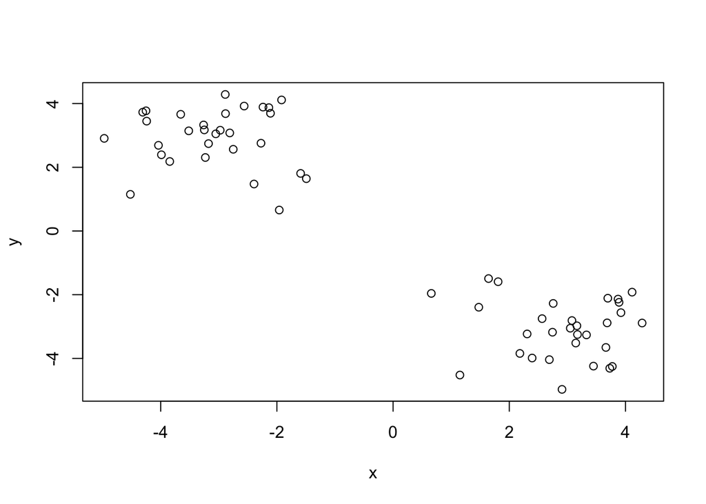

```r
#rnorm makes a random set of data close to -3
tmp <- c(rnorm(30,-3), rnorm(30,3))
#tmp
#hist(tmp)
x<- cbind(x=tmp,y=rev(tmp))
#x
plot(x)
```

> Q. Can we use kmeans() to cluster this data setting k 2 and nstart 20?

```r
km<-kmeans(x,centers=2, nstart=20)
km
```

```
## K-means clustering with 2 clusters of sizes 30, 30
##
## Cluster means:
##           x         y
## 1  2.942967 -3.077052
## 2 -3.077052  2.942967
##
## Clustering vector:
##  [1] 2 2 2 2 2 2 2 2 2 2 2 2 2 2 2 2 2 2 2 2 2 2 2 2 2 2 2 2 2 2 1 1 1 1 1 1 1 1
## [39] 1 1 1 1 1 1 1 1 1 1 1 1 1 1 1 1 1 1 1 1 1 1
##
## Within cluster sum of squares by cluster:
## [1] 48.91488 48.91488
##  (between_SS / total_SS =  91.7 %)
##
## Available components:
##
## [1] "cluster"      "centers"      "totss"        "withinss"     "tot.withinss"
## [6] "betweenss"    "size"         "iter"         "ifault"
```

```r
#clustering vector: says for all the data points which group it belongs to
```

> Q. How many points are in each cluster?

```r
km$size
```

```
## [1] 30 30
```

> Q. What ‘component’ of your result object details cluster assignment/ membership?

```r
km$cluster
```

```
##  [1] 2 2 2 2 2 2 2 2 2 2 2 2 2 2 2 2 2 2 2 2 2 2 2 2 2 2 2 2 2 2 1 1 1 1 1 1 1 1
## [39] 1 1 1 1 1 1 1 1 1 1 1 1 1 1 1 1 1 1 1 1 1 1
```

> Q. What ‘component’ of your result object details cluster centers?

```r
km$centers
```

```
##           x         y
## 1  2.942967 -3.077052
## 2 -3.077052  2.942967
```

> Q. Plot x colored by the kmeans cluster assignment and cluster centers as blue points

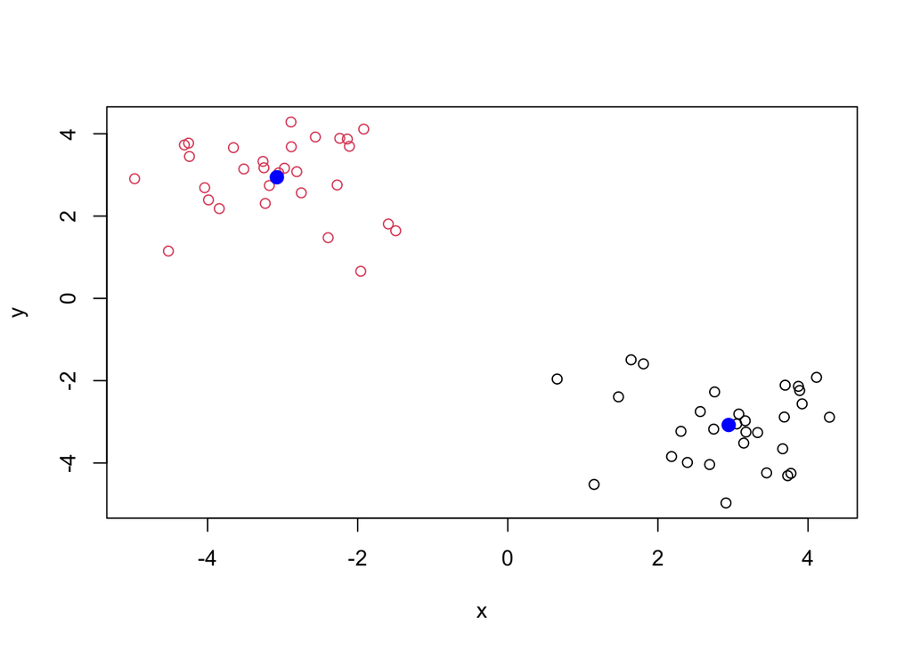

```r
plot(x,col=km$cluster)
points(km$centers, col="blue", pch=20, cex=2)
```

# Hierarchical Clustering

Analuyze this dara with hclust()

Demonstrate the use of dist(), hclust(), plot(), and cutree() functions to do clustering Generate aenarograms and return cluster assignment/ membership vector…

```r
hc<-hclust(dist(x))
hc
```

```
##
## Call:
## hclust(d = dist(x))
##
## Cluster method   : complete
## Distance         : euclidean
## Number of objects: 60
```

There is a plot method for hclust result objects. Let’s see it

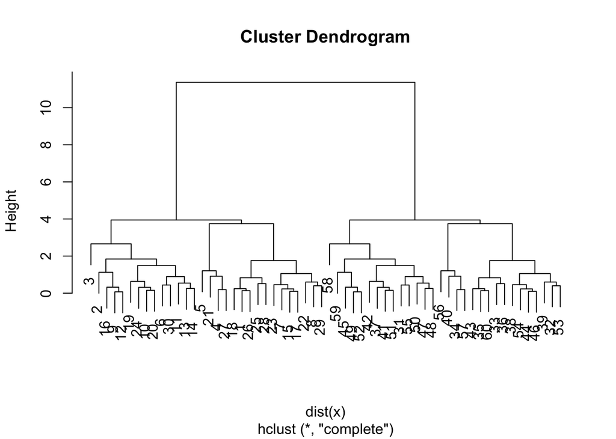

```r
plot(hc)
```

To get our cluster membership vector we have to do a wee bit more work. We have to “cut” the tree with what we think makes sense. For this we use `cutree()` function

```r
cutree(hc,h=6)
```

```
##  [1] 1 1 1 1 1 1 1 1 1 1 1 1 1 1 1 1 1 1 1 1 1 1 1 1 1 1 1 1 1 1 2 2 2 2 2 2 2 2
## [39] 2 2 2 2 2 2 2 2 2 2 2 2 2 2 2 2 2 2 2 2 2 2
```

You can also call `cutree()` setting k=the number of grps/clusters you want

```r
grps<-cutree(hc, k=2)
```

Make our result plot

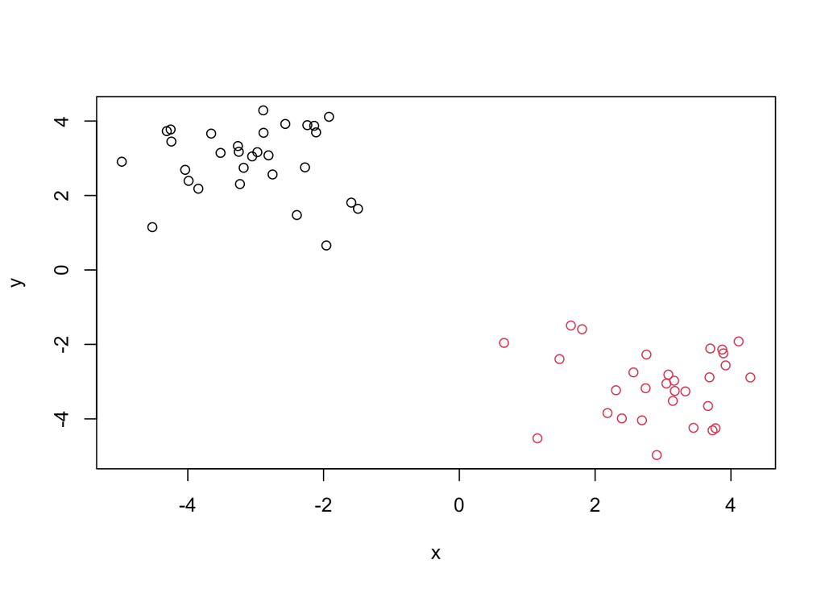

```r
plot(x,col=grps)
```

#Principal Component Analysis (PCA)